# Assignment 6

## Try to submit as an HTML file

Print your Emory code below

```python
# Write your answer here:
#2515643
```

Import the "pandas", "matplotlib.pyplot", "numPy" and "statsmodels.formula.api" libraries

```python
# Write your answer here:

import numpy as np
import matplotlib.pyplot as plt
import pandas as pd
import statsmodels.formula.api as smf
```

(a) Functions

- Read the dataset labelled features.csv.
- Create a `lambda` function that checks if horsepower $>$ 100
- Create a new list that shows true if horsepower $>$ 100 and false  
  if horsepower $\leq$ 100.
- Count how many cars have horsewpower $> 100$.

To get full credit use either the apply or the map function  
(see Lectures 7 and 8)

```python
# Write your answer here


features = pd.read_csv("data/features.csv")

features["horsepower"] = pd.to_numeric(features["horsepower"], errors='coerce')

horsepower_100 = lambda horsepower: horsepower > 100

list_hp100 = list(map(horsepower_100, features["horsepower"]))

np.sum(list_hp100)
```

```
150
```

(b) Subsetting Data

- Read the dataset labelled features.csv.
- Define a global variable called `threshold` that takes the  
  value 3000
- Subset the data to get one dataset with weight $>$ threshold and  
  another with weight $\le$ 3000. Use the `.query()` function.
- Compute the mean acceleration for each of these datasets.

Note: Review how to define a gloabl variable inside `.query()`

```python
# Write your answer here:

threshold = 3000

features_threshold_weight = features.query("weight >= @threshold")
display(features_threshold_weight)
print(np.mean(features_threshold_weight["acceleration"]))

features_threshold_weight_two = features.query("weight <= @threshold")
display(features_threshold_weight_two)
print(np.mean(features_threshold_weight_two["acceleration"]))
```

|  | mpg | cylinders | displacement | horsepower | weight | acceleration | vehicle_id |
| --- | --- | --- | --- | --- | --- | --- | --- |
| 0 | 18.0 | 8 | 307 | 130.0 | 3504 | 12.0 | C-1689780 |
| 1 | 15.0 | 8 | 350 | 165.0 | 3693 | 11.5 | B-1689791 |
| 2 | 18.0 | 8 | 318 | 150.0 | 3436 | 11.0 | P-1689802 |
| 3 | 16.0 | 8 | 304 | 150.0 | 3433 | 12.0 | A-1689813 |
| 4 | 17.0 | 8 | 302 | 140.0 | 3449 | 10.5 | F-1689824 |
| ... | ... | ... | ... | ... | ... | ... | ... |
| 364 | 26.6 | 8 | 350 | 105.0 | 3725 | 19.0 | O-1693784 |
| 365 | 20.2 | 6 | 200 | 88.0 | 3060 | 17.1 | F-1693795 |
| 366 | 17.6 | 6 | 225 | 85.0 | 3465 | 16.6 | C-1693806 |
| 374 | 23.0 | 4 | 151 | NaN | 3035 | 20.5 | A-1693894 |
| 387 | 38.0 | 6 | 262 | 85.0 | 3015 | 17.0 | O-1694037 |

168 rows × 7 columns

```
14.7
```

|  | mpg | cylinders | displacement | horsepower | weight | acceleration | vehicle_id |
| --- | --- | --- | --- | --- | --- | --- | --- |
| 14 | 24.0 | 4 | 113 | 95.0 | 2372 | 15.0 | T-1689934 |
| 15 | 22.0 | 6 | 198 | 95.0 | 2833 | 15.5 | P-1689945 |
| 16 | 18.0 | 6 | 199 | 97.0 | 2774 | 15.5 | A-1689956 |
| 17 | 21.0 | 6 | 200 | 85.0 | 2587 | 16.0 | F-1689967 |
| 18 | 27.0 | 4 | 97 | 88.0 | 2130 | 14.5 | D-1689978 |
| ... | ... | ... | ... | ... | ... | ... | ... |
| 393 | 27.0 | 4 | 140 | 86.0 | 2790 | 15.6 | F-1694103 |
| 394 | 44.0 | 4 | 97 | 52.0 | 2130 | 24.6 | V-1694114 |
| 395 | 32.0 | 4 | 135 | 84.0 | 2295 | 11.6 | D-1694125 |
| 396 | 28.0 | 4 | 120 | 79.0 | 2625 | 18.6 | F-1694136 |
| 397 | 31.0 | 4 | 119 | 82.0 | 2720 | 19.4 | C-1694147 |

230 rows × 7 columns

```
16.202173913043477
```

(c) Regression

In this exercise you are asked to plot acceleration vs. weight and to plot  
the best fit line.

- Run a linear regression between acceleration and weight.
- Extract the intercept and coefficient.
- Using your predicted coefficients, compute the predicted value of acceleration
- Plot a scatter plot with acceleration on the y axis and weight on the x axis.
- On that same figure, plot a line with the predicted values of acceleration

Do not forget to label your axes and title.

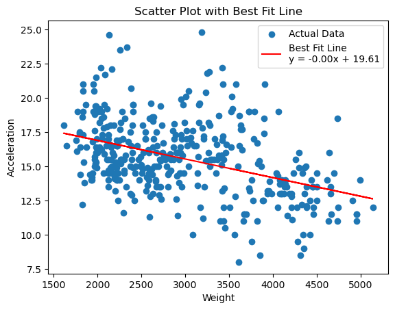

```python
acceleration = features["acceleration"]
weight = features["weight"]


data = {'acceleration': acceleration, 'weight': weight}
df = pd.DataFrame(data)


model = smf.ols(formula='acceleration ~ weight', data=df).fit()


intercept = model.params['Intercept']
coefficient = model.params['weight']

predicted_acceleration = model.predict(df['weight'])


plt.scatter(x=weight, y=acceleration, label='Actual Data')

plt.plot(weight, predicted_acceleration, color='red', label=f'Best Fit Line\ny = {coefficient:.2f}x + {intercept:.2f}')

plt.xlabel('Weight')
plt.ylabel('Acceleration')
plt.title('Scatter Plot with Best Fit Line')
plt.legend()


plt.show()
```

(d) Use sorting + ".iloc[]"

- Read the "fifa23_players_basic.csv" dataset
- Use ".sort_values()" to order the "Age" column  
  from youngest to oldest
- Get a subset with the 5 youngest players

```python
# Write your own code

fifa = pd.read_csv("data/fifa23_players_basic.csv")

fifa_ascendingage = fifa.sort_values(by='Age', ascending=True)

fifa_youngest = fifa_ascendingage.iloc[0:5,:]


display(fifa_ascendingage)

display(fifa_youngest)
```

|  | Known As | Full Name | Overall | Potential | Value(in Euro) | Positions Played | Best Position | Nationality | Image Link | Age | ... | Preferred Foot | Weak Foot Rating | Skill Moves | International Reputation | National Team Name | National Team Image Link | National Team Position | National Team Jersey Number | Attacking Work Rate | Defensive Work Rate |
| --- | --- | --- | --- | --- | --- | --- | --- | --- | --- | --- | --- | --- | --- | --- | --- | --- | --- | --- | --- | --- | --- |
| 17956 | A. Dithmer | Andreas Dithmer | 53 | 76 | 275000 | GK | GK | Denmark | https://cdn.sofifa.net/players/269/573/23_60.png | 16 | ... | Right | 2 | 1 | 1 | - | https://cdn.sofifa.net/flags/dk.png | - | - | Medium | Medium |
| 18014 | J. Ardila | José Ardila | 53 | 73 | 250000 | CM | CAM | Venezuela | https://cdn.sofifa.net/players/268/892/23_60.png | 16 | ... | Right | 3 | 2 | 1 | - | https://cdn.sofifa.net/flags/ve.png | - | - | Medium | Medium |
| 16084 | S. Ngoma | Serge Ngoma | 58 | 82 | 650000 | RW | RM | United States | https://cdn.sofifa.net/players/267/796/23_60.png | 16 | ... | Right | 3 | 2 | 1 | - | https://cdn.sofifa.net/flags/us.png | - | - | High | Medium |
| 11481 | O. Vargas | Obed Vargas | 64 | 81 | 1500000 | CM,CDM,RM | CAM | United States | https://cdn.sofifa.net/players/263/701/23_60.png | 16 | ... | Right | 3 | 3 | 1 | - | https://cdn.sofifa.net/flags/us.png | - | - | High | Medium |
| 17591 | A. Madaliński | Alan Madaliński | 54 | 68 | 210000 | GK | GK | Poland | https://cdn.sofifa.net/players/270/590/23_60.png | 16 | ... | Right | 3 | 1 | 1 | - | https://cdn.sofifa.net/flags/pl.png | - | - | Medium | Medium |
| ... | ... | ... | ... | ... | ... | ... | ... | ... | ... | ... | ... | ... | ... | ... | ... | ... | ... | ... | ... | ... | ... |
| 2423 | Rubén Castro | Rubén Castro Martín | 73 | 73 | 0 | ST | ST | Spain | https://cdn.sofifa.net/players/115/909/23_60.png | 41 | ... | Right | 3 | 3 | 2 | - | https://cdn.sofifa.net/flags/es.png | - | - | Medium | Low |
| 4499 | G. Pegolo | Gianluca Pegolo | 70 | 70 | 180000 | GK | GK | Italy | https://cdn.sofifa.net/players/106/795/23_60.png | 41 | ... | Left | 2 | 1 | 1 | - | https://cdn.sofifa.net/flags/it.png | - | - | Medium | Medium |
| 3276 | S. Torrico | Sebastián Torrico | 72 | 72 | 250000 | GK | GK | Argentina | https://cdn.sofifa.net/players/216/692/23_60.png | 42 | ... | Right | 2 | 1 | 1 | - | https://cdn.sofifa.net/flags/ar.png | - | - | Medium | Medium |
| 13548 | S. Lukić | Stojan Lukić | 62 | 62 | 45000 | GK | GK | Bosnia and Herzegovina | https://cdn.sofifa.net/players/213/483/23_60.png | 42 | ... | Right | 2 | 1 | 1 | - | - | - | - | Medium | Medium |
| 592 | G. Buffon | Gianluigi Buffon | 79 | 79 | 1900000 | GK | GK | Italy | https://cdn.sofifa.net/players/001/179/23_60.png | 44 | ... | Right | 2 | 1 | 4 | - | https://cdn.sofifa.net/flags/it.png | - | - | Medium | Medium |

18539 rows × 32 columns

|  | Known As | Full Name | Overall | Potential | Value(in Euro) | Positions Played | Best Position | Nationality | Image Link | Age | ... | Preferred Foot | Weak Foot Rating | Skill Moves | International Reputation | National Team Name | National Team Image Link | National Team Position | National Team Jersey Number | Attacking Work Rate | Defensive Work Rate |
| --- | --- | --- | --- | --- | --- | --- | --- | --- | --- | --- | --- | --- | --- | --- | --- | --- | --- | --- | --- | --- | --- |
| 17956 | A. Dithmer | Andreas Dithmer | 53 | 76 | 275000 | GK | GK | Denmark | https://cdn.sofifa.net/players/269/573/23_60.png | 16 | ... | Right | 2 | 1 | 1 | - | https://cdn.sofifa.net/flags/dk.png | - | - | Medium | Medium |
| 18014 | J. Ardila | José Ardila | 53 | 73 | 250000 | CM | CAM | Venezuela | https://cdn.sofifa.net/players/268/892/23_60.png | 16 | ... | Right | 3 | 2 | 1 | - | https://cdn.sofifa.net/flags/ve.png | - | - | Medium | Medium |
| 16084 | S. Ngoma | Serge Ngoma | 58 | 82 | 650000 | RW | RM | United States | https://cdn.sofifa.net/players/267/796/23_60.png | 16 | ... | Right | 3 | 2 | 1 | - | https://cdn.sofifa.net/flags/us.png | - | - | High | Medium |
| 11481 | O. Vargas | Obed Vargas | 64 | 81 | 1500000 | CM,CDM,RM | CAM | United States | https://cdn.sofifa.net/players/263/701/23_60.png | 16 | ... | Right | 3 | 3 | 1 | - | https://cdn.sofifa.net/flags/us.png | - | - | High | Medium |
| 17591 | A. Madaliński | Alan Madaliński | 54 | 68 | 210000 | GK | GK | Poland | https://cdn.sofifa.net/players/270/590/23_60.png | 16 | ... | Right | 3 | 1 | 1 | - | https://cdn.sofifa.net/flags/pl.png | - | - | Medium | Medium |

5 rows × 32 columns

(e) Use queries + global variables

- Read the "fifa23_players_basic.csv" dataset
- Compute the mean of the column "Value(in Euro)"  
  and store it as a variable
- Subset the players whose value is above the mean value  
  using ".query()"

HINT: Remember that there is a special syntax for  
when the column names have spaces (see Lecture 10)  
Reference the column as `` `Value(in Euro)` `` inside .query()

```python
# Write your own code

mean_euro = np.mean(fifa["Value(in Euro)"])
print(mean_euro)

threshold = mean_euro

greater_mean_euro = fifa.query("`Value(in Euro)` > @threshold")

display(greater_mean_euro)
```

```
2875461.4033658775
```

|  | Known As | Full Name | Overall | Potential | Value(in Euro) | Positions Played | Best Position | Nationality | Image Link | Age | ... | Preferred Foot | Weak Foot Rating | Skill Moves | International Reputation | National Team Name | National Team Image Link | National Team Position | National Team Jersey Number | Attacking Work Rate | Defensive Work Rate |
| --- | --- | --- | --- | --- | --- | --- | --- | --- | --- | --- | --- | --- | --- | --- | --- | --- | --- | --- | --- | --- | --- |
| 0 | L. Messi | Lionel Messi | 91 | 91 | 54000000 | RW | CAM | Argentina | https://cdn.sofifa.net/players/158/023/23_60.png | 35 | ... | Left | 4 | 4 | 5 | Argentina | https://cdn.sofifa.net/flags/ar.png | RW | 10 | Low | Low |
| 1 | K. Benzema | Karim Benzema | 91 | 91 | 64000000 | CF,ST | CF | France | https://cdn.sofifa.net/players/165/153/23_60.png | 34 | ... | Right | 4 | 4 | 4 | France | https://cdn.sofifa.net/flags/fr.png | ST | 19 | Medium | Medium |
| 2 | R. Lewandowski | Robert Lewandowski | 91 | 91 | 84000000 | ST | ST | Poland | https://cdn.sofifa.net/players/188/545/23_60.png | 33 | ... | Right | 4 | 4 | 5 | Poland | https://cdn.sofifa.net/flags/pl.png | ST | 9 | High | Medium |
| 3 | K. De Bruyne | Kevin De Bruyne | 91 | 91 | 107500000 | CM,CAM | CM | Belgium | https://cdn.sofifa.net/players/192/985/23_60.png | 31 | ... | Right | 5 | 4 | 4 | Belgium | https://cdn.sofifa.net/flags/be.png | RF | 7 | High | High |
| 4 | K. Mbappé | Kylian Mbappé | 91 | 95 | 190500000 | ST,LW | ST | France | https://cdn.sofifa.net/players/231/747/23_60.png | 23 | ... | Right | 4 | 5 | 4 | France | https://cdn.sofifa.net/flags/fr.png | ST | 10 | High | Low |
| ... | ... | ... | ... | ... | ... | ... | ... | ... | ... | ... | ... | ... | ... | ... | ... | ... | ... | ... | ... | ... | ... |
| 7066 | F. Rieder | Fabian Rieder | 68 | 83 | 2900000 | CAM,CM | CAM | Switzerland | https://cdn.sofifa.net/players/259/306/23_60.png | 20 | ... | Left | 3 | 2 | 1 | - | https://cdn.sofifa.net/flags/ch.png | - | - | High | Medium |
| 7071 | J. Bakayoko | Johan Bakayoko | 68 | 85 | 3100000 | RW | LM | Belgium | https://cdn.sofifa.net/players/265/450/23_60.png | 19 | ... | Left | 3 | 3 | 1 | - | https://cdn.sofifa.net/flags/be.png | - | - | High | Medium |
| 7090 | M. Arezo | Matías Arezo | 68 | 81 | 2900000 | ST,CAM | ST | Uruguay | https://cdn.sofifa.net/players/254/653/23_60.png | 19 | ... | Right | 3 | 4 | 1 | - | https://cdn.sofifa.net/flags/uy.png | - | - | High | Medium |
| 7096 | Y. Kallon | Yayah Kallon | 68 | 82 | 3000000 | RM,RW,CF | ST | Sierra Leone | https://cdn.sofifa.net/players/262/333/23_60.png | 21 | ... | Left | 2 | 3 | 1 | - | - | - | - | High | Low |
| 7168 | M. Soulé | Matías Soulé | 68 | 85 | 3100000 | RW | LM | Argentina | https://cdn.sofifa.net/players/265/695/23_60.png | 19 | ... | Left | 4 | 4 | 1 | - | https://cdn.sofifa.net/flags/ar.png | - | - | High | Medium |

3216 rows × 32 columns